# 2010-2015 Ar-Ge Faaliyet İstatistikleri

Funda GÜVEN & Merve YAVUZ

7 Şubat 2017

Çalışmamız TÜIK verilerinden faydalanarak yapılmıştır.2010-2015 yılları arasnda belli sektörlerde ARGE faaliyetleri için yapılan harcamaları görselleştirme amaçlı R üzerinde kodlama ile bazı grafikler elde edilmiştir. Öncelikle tüm sektörlerde ARGE toplam harcama tutarları yıllara göre gösterilmiştir. Ardından Sektörlere göre gruplandırma yapılıp harcamaların detaylı kırılımları gösterilmiştir. Daha sonra harcama türüne göre sektörel paylar verilmiştir.

Grafik 1:

Aşağıdaki kod kullanılarak yıllara göre toplam ARGE harcamalarını görmek adına sütun grafik oluşturulmuştur.

```r
library(tidyverse)
library(readxl)
```

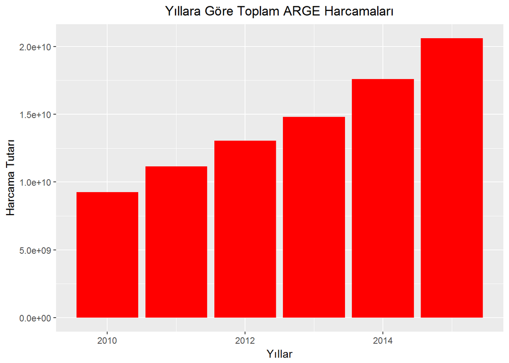

```r
tablo<-read_excel("data.xls")
tum_toplam <- tablo %>% filter(tur == 'tumu')
gra_toplam <- ggplot(data=tum_toplam,aes(x=yil,y=toplam)) + geom_bar(stat="identity",fill="red")
gra_toplam+
  labs(x="Yıllar",y="Harcama Tutarı",title="Yıllara Göre Toplam ARGE Harcamaları")+
  theme(legend.position = "top",plot.title = element_text(hjust=0.5))
```

- Grafikte de görüleceği üzere 2013 yılından sonra tüm sektörler genelinde ülkemizde ARGE harcamalarında büyük artış gözlemlenmiştir.

Grafik 2:

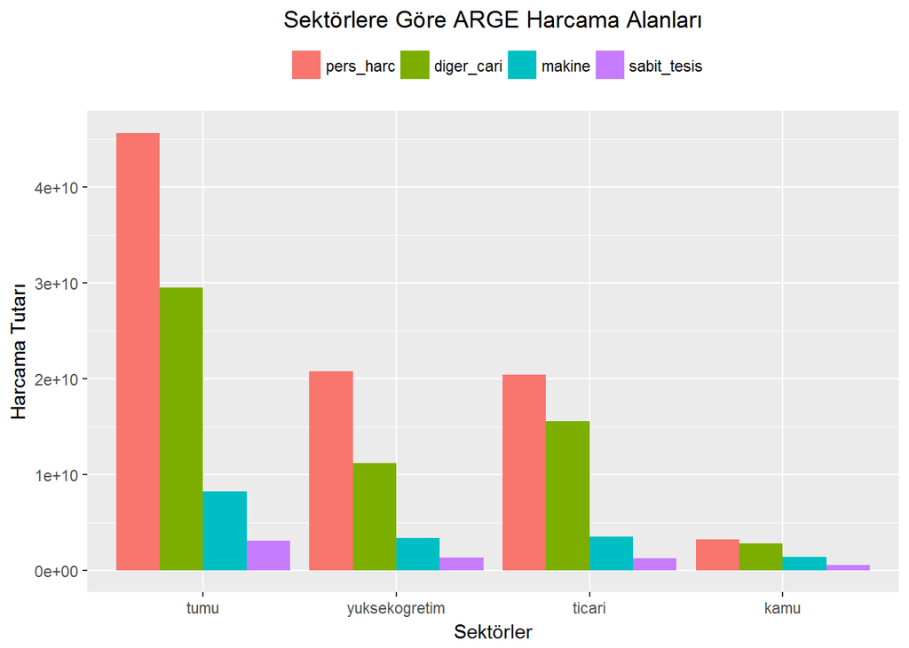

```r
 sektorler_alanlar=tablo %>%
  select (tur,pers_harc,diger_cari,makine,sabit_tesis)%>%
  gather(key=parametre,value=deger,-tur)%>%
  group_by(tur,parametre) %>%
  summarise(deger=sum(deger))

sektor_harc_graf= ggplot(data=sektorler_alanlar,
          aes(x=ordered(tur,levels=c("tumu","yuksekogretim","ticari","kamu")),y=deger,
          fill=ordered(parametre,levels=c("pers_harc","diger_cari","makine","sabit_tesis"))))+
          geom_bar(stat="identity",position="dodge") + labs(fill="")

sektor_harc_graf+
  labs(x="Sektörler",y="Harcama Tutarı",title="Sektörlere Göre ARGE Harcama Alanları")+
  theme(legend.position = "top",plot.title = element_text(hjust=0.5))
```

- Tüm sektörlerde personel harcamasının başı çektiği gözlemlenmektedir. Ayrıca ticari alandaki ARGE harcamalarının diğer sektörlere göre en fazla paya sahip olduğu izlenebilir. Kamu sektörü ise ARGE harcamalarında büyük oranda geri kalmaktadır.

Aşağıda sektör bazında yapılan toplam arge harcamalarının yıllara göre değişiminin izlenebileceği grafik oluşturulmuştur.

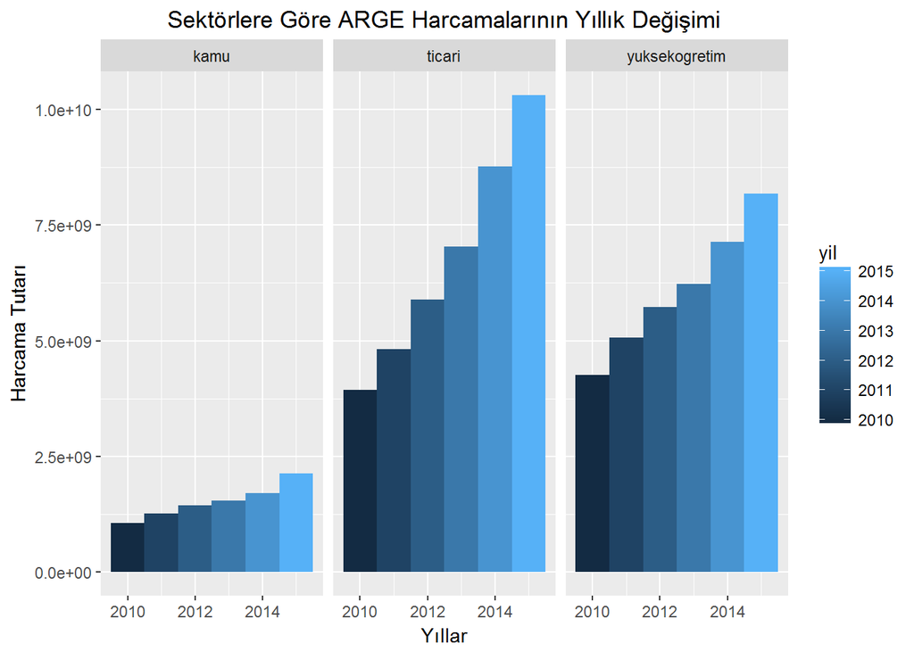

```r
yil_data=tablo %>% filter(tur != 'tumu')
gra_yillar <- ggplot(yil_data, aes(x=yil, y=toplam, fill=yil))+
geom_bar(width = 1, stat = "identity")+
facet_wrap(~tur)
gra_yillar+
 labs(x="Yıllar",y="Harcama Tutarı",title="Sektörlere Göre ARGE Harcamalarının Yıllık Değişimi")+
  theme(plot.title = element_text(hjust=0.5))
```

- Kamu sektörüne bakıldığında ARGE harcamalarına ayırdığı bütçenin düşüklüğünün yanısıra yıllar içerisinde de harcamalarında dikkat çeken bir artış görülmemektedir. Ticari ise zamanla ARGE harcamalarını yüksek oranda arttırmıştır.

Aşağıda harcama alanlarına göre ayrı ayrı tüm sektörlerin ilgili harcama alanlarında payları gösterilmiştir.

Grafik 3: Personel harcamalarına göre sektörlerin yüzdesel dağılımı

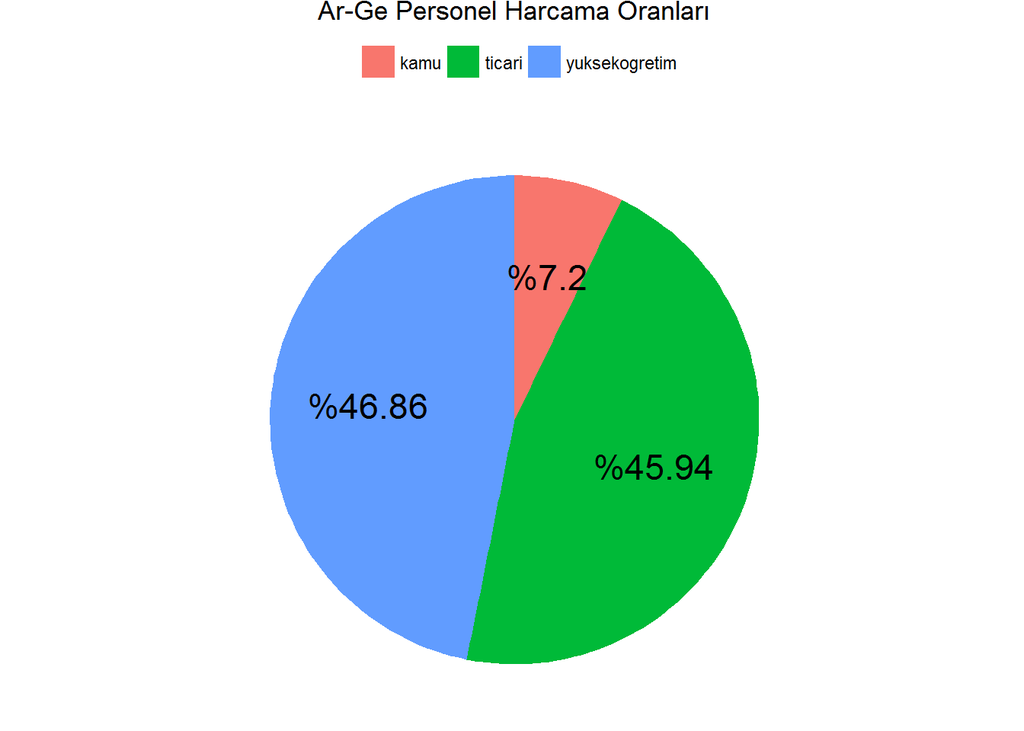

```r
per <- tablo %>%  group_by(tur) %>% summarise(pers_harc=sum(pers_harc))
pper <-  per %>% filter(tur != 'tumu')

pper2<-
  pper%>%
  mutate(pers_harc_yuzde=pers_harc/sum(pers_harc),
         pers_harc_position = 1-(cumsum(pers_harc_yuzde)-pers_harc_yuzde/2))

p<- ggplot(pper2, aes(x="", y=pers_harc_yuzde, fill=tur))+
  geom_bar(width = 1, stat = "identity")

pie_pers <- p + coord_polar("y",direction=-1) +
  theme_void() +
  geom_text(aes(label = paste0("%",round(pers_harc_yuzde,4)*100),y=pers_harc_position,x=1.1),size=6,angle=0) +
  labs(fill="", title="Ar-Ge Personel Harcama Oranları") +
  theme(legend.position="top",
        plot.title=element_text(hjust=0.5))
pie_pers
```

Grafik 4: Diğer cari harcamalara göre sektörlerin yüzdesel dağılımı

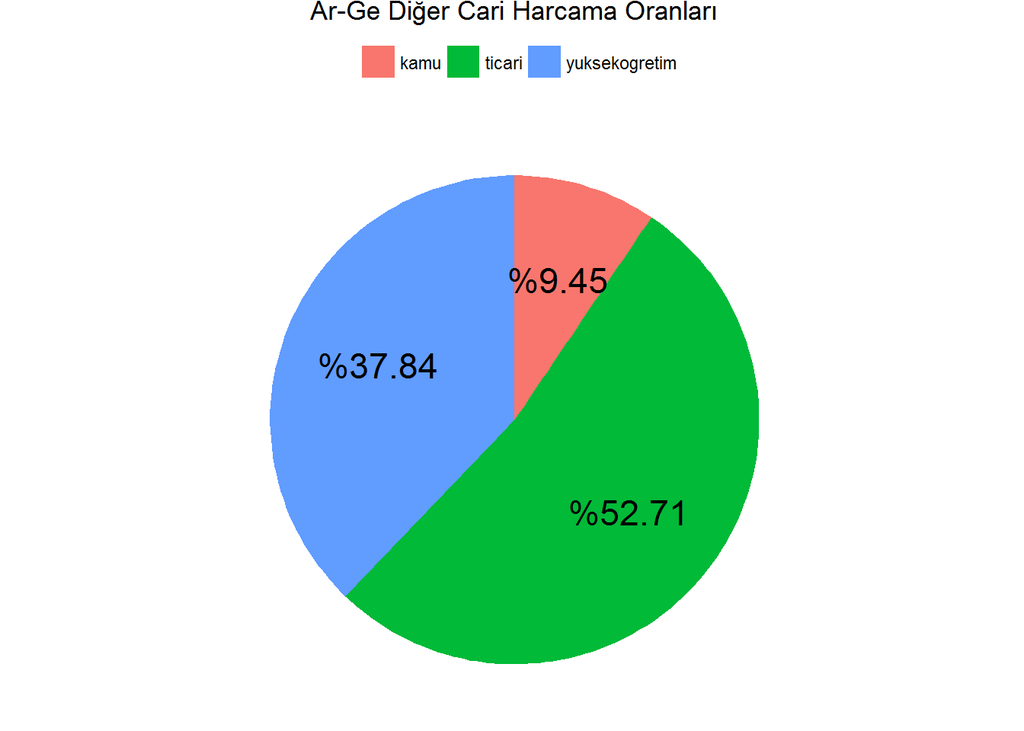

```r
cari <- tablo %>%  group_by(tur) %>% summarise(cari_harc=sum(diger_cari))
ccari <-  cari %>% filter(tur != 'tumu')

ccari2<-
  ccari%>%
  mutate(cari_harc_yuzde=cari_harc/sum(cari_harc),
         cari_harc_position = 1-(cumsum(cari_harc_yuzde)-cari_harc_yuzde/2))

p<- ggplot(ccari2, aes(x="", y=cari_harc_yuzde, fill=tur))+
  geom_bar(width = 1, stat = "identity")

pie_cari <- p + coord_polar("y",direction=-1) +
  theme_void() +
  geom_text(aes(label = paste0("%",round(cari_harc_yuzde,4)*100),y=cari_harc_position,x=1.1),size=6,angle=0) +
  labs(fill="", title="Ar-Ge Diğer Cari Harcama Oranları") +
  theme(legend.position="top",
        plot.title=element_text(hjust=0.5))
pie_cari
```

Grafik 5: Makine Teçhizat harcamalarına göre sektörlerin yüzdesel dağılımı

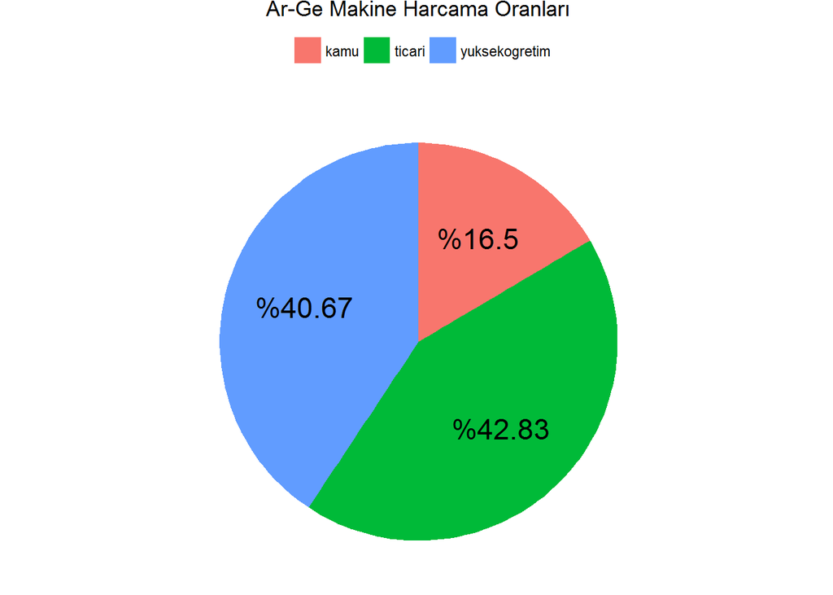

```r
makine <- tablo %>%  group_by(tur) %>% summarise(makine_harc=sum(makine))
mmakine <-  makine %>% filter(tur != 'tumu')

mmakine2<-
  mmakine %>%
  mutate(makine_harc_yuzde=makine_harc/sum(makine_harc),
         makine_harc_position = 1-(cumsum(makine_harc_yuzde)-makine_harc_yuzde/2))

p<- ggplot(mmakine2, aes(x="", y=makine_harc_yuzde, fill=tur))+
  geom_bar(width = 1, stat = "identity")

pie_makine <- p + coord_polar("y",direction=-1) +
  theme_void() +
  geom_text(aes(label = paste0("%",round(makine_harc_yuzde,4)*100),y=makine_harc_position,x=1.1),size=6,angle=0) +
  labs(fill="", title="Ar-Ge Makine Harcama Oranları") +
  theme(legend.position="top",
        plot.title=element_text(hjust=0.5))
pie_makine
```

Grafik 6: Sabit tesis harcamalarına göre sektörlerin yüzdesel dağılımı

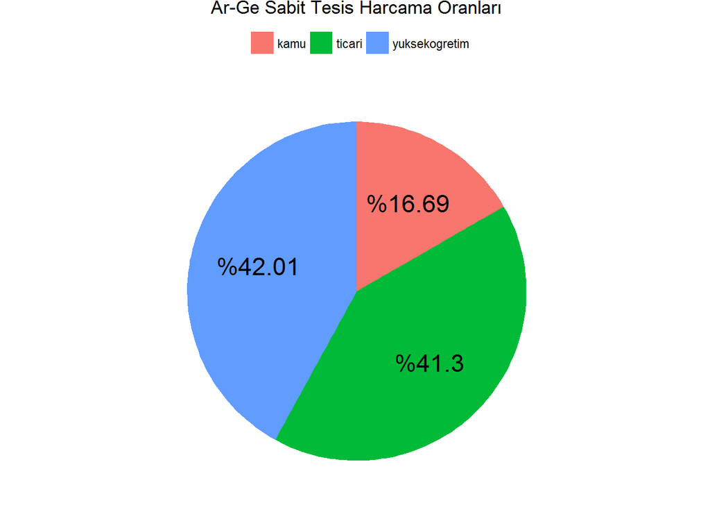

```r
tesis <- tablo %>%  group_by(tur) %>% summarise(tesis_harc=sum(sabit_tesis))
ttesis <-  tesis %>% filter(tur != 'tumu')

ttesis2<-
  ttesis %>%
  mutate(tesis_harc_yuzde=tesis_harc/sum(tesis_harc),
         tesis_harc_position = 1-(cumsum(tesis_harc_yuzde)-tesis_harc_yuzde/2))

p<- ggplot(ttesis2, aes(x="",y=tesis_harc_yuzde, fill=tur))+
  geom_bar(width = 1, stat = "identity")

pie_tesis <- p +  coord_polar("y",direction=-1) +
  theme_void() +
  geom_text(aes(label = paste0("%",round(tesis_harc_yuzde,4)*100),y=tesis_harc_position,x=1.1),size=6,angle=0) +
  labs(fill="", title="Ar-Ge Sabit Tesis Harcama Oranları") +
  theme(legend.position="top",
        plot.title=element_text(hjust=0.5))
pie_tesis
```